[figure not shown]

# Executive Summary

This study examines two datasets: one from the London Fire Brigade with fire incident data and another with UK Food Standards Agency restaurant ratings. The aim was to determine if restaurant density or food safety ratings correlate with fire incidents. The analysis revealed that areas with more restaurants experienced more fire incidents, but food safety ratings did not significantly impact fire occurrence. In summary, this study sheds light on the link between restaurant density, safety ratings, and fire incidents in London, emphasizing the importance of vigilance in densely populated restaurant areas, irrespective of safety ratings.

# Problem Statement

In the aftermath of a fire, food is likely to be contaminated by three factors: the heat from the fire, smoke fumes, and the chemicals used to fight fires. The heat can activate food spoilage bacteria and break food packaging, while smoke and chemicals can poison food and render it unsafe for consumption. Fire also destroys storage, appliances, and equipment that can otherwise protect food from contaminants. Therefore, food safety should be a primary concern of food establishments after a fire incident.

Conversely, the team would also like to know whether food establishments with low food safety ratings are prone to fire incidents.

Curious about the state of food safety in London in relation to fire incidents, the team aims to investigate the following problem statement:

Is there a connection between fire incident reports and food safety ratings in London?

*Hypotheses:*

1. There is a significant correlation between the density of food establishments in a post-code district to the number of fire incident reports in that district.
2. There is a significant correlation between the average food safety rating in a post-code district to the number of fire incident reports in that district.

# Data Sources and Description

The team used two datasets: the UK food hygiene rating datasets for London from the Food Standards Agency’s official website, and the London Fire Brigade Incident Records from the London Datastore, specifically the versions available via the jojie-collected public datasets of the Asian Institute of Management (AIM).

## [UK Food Hygiene Rating (London)](https://www.data.gov.uk/search?filters%5Bpublisher%5D=Food+Standards+Agency)

The UK food hygiene rating (London) dataset provides information on the latest food hygiene rating or inspection result of each food establishment by the local authority in London. These food establishments include restaurants, pubs, takeaways/fast food restaurants, cafés, hotels and other places consumers eat, as well as supermarkets and other food shops. For each establishment, the dataset provides its name, establishment type, location, latest date of inspection, hygiene rating (0 being the lowest and 5 being the highest), and rating score breakdown.

Figure 1. Description of Score Types in the UK Food Hygiene Rating

| Score Type | Description |
| --- | --- |
| Hygiene | how food is stored, cooked, prepared, etc. |
| Structural | ventilation, pest management, cleanliness, etc. |
| Confidence | in management: capability of management regarding food safety such as review of food safety practices, keeping cleaning records, training of staff, and so on. |

The column info of the UK Food Hygiene Rating Dataset is shown below:

Figure 2. Column information of the UK Food Hygiene Rating Dataset

| # | Column | Non-Null Count | Dtype | Description |
| --- | --- | --- | --- | --- |
| 0 | FHRSID | 78714 non-null | object | Index |
| 1 | LocalAuthorityBusinessID | 78714 non-null | object | Business ID* |
| 2 | BusinessName | 78714 non-null | object | Business Name |
| 3 | BusinessType | 78714 non-null | object | Business Type (Restaurant, Bar, etc.)* |
| 4 | BusinessTypeID | 78714 non-null | object | Business Type ID |
| 5 | RatingValue | 78714 non-null | int64 | Rating* |
| 6 | RatingKey | 78714 non-null | object | Rating ID |
| 7 | RatingDate | 70420 non-null | object | Rating Date |
| 8 | LocalAuthorityCode | 78714 non-null | object | Local Authority Code |
| 9 | LocalAuthorityName | 78714 non-null | object | Local Authority Name |
| 10 | LocalAuthorityWebsite | 78714 non-null | object | Local Authority Website |
| 11 | LocalAuthorityEmailAddress | 78714 non-null | object | Local Authority Email Address |
| 12 | Scores_Hygiene | 66941 non-null | float64 | Hygeine Score*+ |
| 13 | Scores_Structural | 66941 non-null | float64 | Structural Score*+ |
| 14 | Scores_ConfidenceInManagement | 66941 non-null | float64 | Confidence in Management Score*+ |
| 15 | SchemeType | 56492 non-null | object | SchemeType |
| 16 | NewRatingPending | 56492 non-null | object | New Rating Pending |
| 17 | AddressLine1 | 56228 non-null | object | Address Line 1 |
| 18 | AddressLine2 | 59137 non-null | object | Address Line 2 |
| 19 | AddressLine3 | 39445 non-null | object | Address Line 3 |
| 20 | PostCode | 68592 non-null | object | Postcode* |
| 21 | Geocode_Longitude | 63933 non-null | object | Longitude* |
| 22 | Geocode_Latitude | 63933 non-null | object | Latitude* |
| 23 | RightToReply | 10 non-null | object | Reply of Business |
| 24 | AddressLine4 | 26025 non-null | object | Address Line 4 |

*\* Used in the study.*  
*+ Scores represent areas of improvement; the lower the better.*

## [London Fire Brigade Incident Records](https://data.london.gov.uk/dataset/london-fire-brigade-incident-records)

The London Fire Brigade Incident Records dataset provides the details of every incident which the London Fire Brigade attended since January 1st, 2009. For each incident, the dataset provides the date, location, and type of incident, which can be sorted into three: fire, false alarm, and special services.

The column info of the London Fire Brigade Incident Records Dataset is shown below:

Figure 3. Column information of the London Fire Brigade Incident Records Dataset

| # | Column | Non-Null Count | Dtype | Description |
| --- | --- | --- | --- | --- |
| 0 | DateOfCall | 53382 non-null | object | Date of 999 call |
| 1 | IncidentGroup | 53382 non-null | object | High level incident category* |
| 2 | StopCodeDescription | 53382 non-null | object | Detailed incident category |
| 3 | SpecialServiceType | 0 non-null | object | Further detail for special services incident categories |
| 4 | PropertyCategory | 53382 non-null | object | High level property descriptor* |
| 5 | PropertyType | 53382 non-null | object | Detailed property descriptor* |
| 6 | AddressQualifier | 53382 non-null | object | Qualifies location of actual incident relevant to category above |
| 7 | Postcode_full | 48077 non-null | object | Postcode |
| 8 | Postcode_district | 53382 non-null | object | Postcode District* |
| 9 | IncGeo_BoroughCode | 53382 non-null | object | Borough Code |
| 10 | IncGeo_BoroughName | 53382 non-null | object | Borough Name |
| 11 | ProperCase | 53382 non-null | object | Borough Name |
| 12 | IncGeo_WardCode | 53377 non-null | object | Ward Code |
| 13 | IncGeo_WardName | 53377 non-null | object | Ward Name |
| 14 | IncGeo_WardNameNew | 53377 non-null | object | New Ward Name |
| 15 | Latitude | 48077 non-null | float64 | Latitude* |
| 16 | Longitude | 48077 non-null | float64 | Longitude* |
| 17 | FRS | 53382 non-null | object | Fire Service ground |
| 18 | IncidentStationGround | 53382 non-null | object | LFB Station ground |
| 19 | Notional Cost | 53382 non-null | int64 | Time spent multiplied by notional annual cost of a pump |
| 20 | Postcode_area | 49172 non-null | object | Postcode Area* |

*\* Used in the study.*

# Methodology

## Import Datasets to pandas Dataframe

### UK Food Hygiene Rating (London)

The dataset was comprised of several XML files, so the team defined a function "XML-to-Dataframe" that converted these files into a pandas dataframe to prepare the dataset for cleaning. This function took all establishment details and extracted the hygiene scores and geocodes necessary for our study.

Filepaths were listed of all XML files for each borough in London which was used by the "XML-to-Dataframe" function to combine to a single dataframe.

A preview of the UK Food Hygiene Rating Dataset is shown below:

Figure 4. Preview of UK Food Hygiene Rating Dataset

### London Fire Brigade Incidents Dataset

The London Fire Brigade Incidents Dataset was stored in a csv file. Pandas function "read_csv" was used to parse the contents of the file.

[output not shown]

A preview of the London Fire Brigade Incidents Dataset is shown below:

Figure 5. Preview of London Fire Brigade Incidents Dataset

|  | 0 | 1 | 2 | 3 | 4 | 5 | 6 | 7 | 8 | 9 | ... | 29 | 30 | 31 | 32 | 33 | 34 | 35 | 36 | 37 | 38 |
| --- | --- | --- | --- | --- | --- | --- | --- | --- | --- | --- | --- | --- | --- | --- | --- | --- | --- | --- | --- | --- | --- |
| 0 | 235138081 | 2009-01-01 | 2009 | 00:00:37 | 0 | Special Service | Special Service | RTC | Road Vehicle | Car | ... | 319.0 | Battersea | 342.0 | Clapham | 2.0 | 2.0 | 2 | 60 | 255 | 1.0 |
| 1 | 1091 | 2009-01-01 | 2009 | 00:00:46 | 0 | Special Service | Special Service | Assist other agencies | Outdoor | Lake/pond/reservoir | ... | NaN | NaN | NaN | NaN | NaN | NaN | 1 | 60 | 255 | 1.0 |
| 2 | 2091 | 2009-01-01 | 2009 | 00:03:00 | 0 | Fire | Secondary Fire | NaN | Outdoor | Road surface/pavement | ... | 308.0 | Edmonton | NaN | NaN | 1.0 | 1.0 | 1 | 60 | 255 | 2.0 |
| 3 | 3091 | 2009-01-01 | 2009 | 00:04:27 | 0 | Fire | Secondary Fire | NaN | Outdoor | Domestic garden (vegetation not equipment) | ... | 210.0 | Hillingdon | NaN | NaN | 1.0 | 1.0 | 1 | 60 | 255 | 2.0 |
| 4 | 5091 | 2009-01-01 | 2009 | 00:05:39 | 0 | Fire | Secondary Fire | NaN | Outdoor | Cycle path/public footpath/bridleway | ... | 233.0 | Holloway | 250.0 | Holloway | 1.0 | 2.0 | 2 | 60 | 255 | 1.0 |

5 rows × 39 columns

## Data Cleaning

### UK Food Hygiene Rating Dataset

The team began cleaning the dataset by removing the columns not pertinent to our study. We kept establishment ratings and geocodes, as they were the most relevant data for our investigation. Then, we removed unnecessary rows that contained incomplete geocodes and establishments that had yet to receive a rating. We also applied the correct dtypes to the data and cleaned up lowercase postcodes for convenience and consistency. Finally, we added two new derived columns to our dataset: PostCode_District and PostCode_Area, which enabled us to search and sort our data further by location.

The column info of table `hygiene` to be used in the study is shown below:

Figure 6. Columns of **hygiene** table

| # | Column | Non-Null Count | Dtype |
| --- | --- | --- | --- |
| 0 | FHRSID | 56492 non-null | object |
| 1 | LocalAuthorityBusinessID | 56492 non-null | object |
| 2 | BusinessName | 56492 non-null | object |
| 3 | BusinessType | 56492 non-null | object |
| 4 | RatingValue | 56492 non-null | int64 |
| 5 | RatingKey | 56492 non-null | object |
| 6 | RatingDate | 56492 non-null | datetime64 |
| 7 | LocalAuthorityCode | 56492 non-null | object |
| 8 | LocalAuthorityName | 56492 non-null | object |
| 9 | NewRatingPending | 56492 non-null | object |
| 10 | PostCode | 55930 non-null | object |
| 11 | Scores_Hygiene | 55803 non-null | float64 |
| 12 | Scores_Structural | 55803 non-null | float64 |
| 13 | Scores_ConfidenceInManagement | 55803 non-null | float64 |
| 14 | Geocode_Longitude | 56492 non-null | object |
| 15 | Geocode_Latitude | 56492 non-null | object |
| 16 | PostCode_District | 49827 non-null | object |
| 17 | PostCode_Area | 49827 non-null | object |

### London Fire Brigade Incident Records Dataset

The column info of table `fire` to be used in the study is shown below:

Figure 7. Columns of **fire** table

| # | Column | Non-Null Count | Dtype |
| --- | --- | --- | --- |
| 0 | DateOfCall | 54436 non-null | datetime64 |
| 1 | IncidentGroup | 54436 non-null | object |
| 2 | StopCodeDescription | 54436 non-null | object |
| 3 | SpecialServiceType | 0 non-null | object |
| 4 | PropertyCategory | 54436 non-null | object |
| 5 | PropertyType | 54436 non-null | object |
| 6 | AddressQualifier | 54436 non-null | object |
| 7 | Postcode_full | 49131 non-null | object |
| 8 | Postcode_district | 54436 non-null | object |
| 9 | IncGeo_BoroughCode | 54436 non-null | object |
| 10 | IncGeo_BoroughName | 54436 non-null | object |
| 11 | ProperCase | 54436 non-null | object |
| 12 | IncGeo_WardCode | 54431 non-null | object |
| 13 | IncGeo_WardName | 54431 non-null | object |
| 14 | IncGeo_WardNameNew | 54431 non-null | object |
| 15 | Latitude | 49131 non-null | float64 |
| 16 | Longitude | 49131 non-null | float64 |
| 17 | FRS | 54436 non-null | object |
| 18 | IncidentStationGround | 54436 non-null | object |
| 19 | Notional Cost | 54436 non-null | int64 |
| 20 | Postcode_area | 50152 non-null | object |

## Exploratory Data Analysis

### Creation of DataFrame for tables `fire` and `hygiene`

### Exploring the `hygiene` table

Top 10 business types of UK food establishments with ratings from the Food Standards Agency are shown below:

Figure 8. Top 10 business types of UK food establishments with ratings

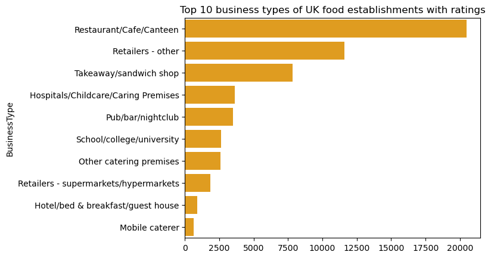

### Exploring the `fire` table

The top 10 "propertyType"s that had fire incidents is shown below.

*Note: The "Restaurant/cafe" and "Pub/wine bar/bar" were also considered as "BusinessType" in the hygiene table.*

Figure 9. Top 10 property types with Fire Incidents

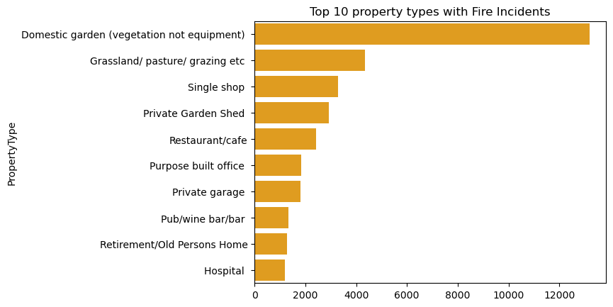

The graph below shows the count of fire incidents on Restaurant/Cafe/Canteen per Area:

Figure 10. Count of fire incident on Restaurant/Cafe/Canteen per Area

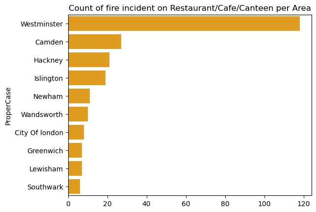

### Data Analysis

This graph displays some correlation between the number of establishments and the number of fire incidents within each postcode district. The more establishments in a postcode, the more fire incidents reported.

Figure 11. No. of Fire Incidents per Postcode District vs. No. of Food Establishments  
Pearson correlation coefficient: 0.7952

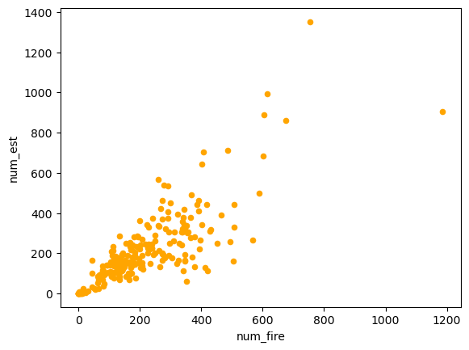

This graph shows little correlation between an establishment’s hygiene score and the number of fire incidents per postcode district. The most common hygiene score ranges from 2 to 6.

Figure 12. No. of Fire Incidents per Postcode District vs Ave Hygiene Score (Lower is Better)  
Pearson correlation coefficient: 0.0151

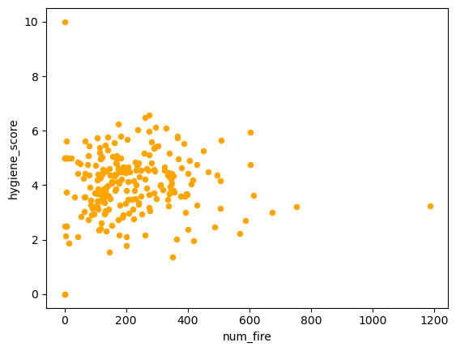

This graph shows little correlation between an establishment’s structural score and the number of fire incidents per postcode district. The most common structural score is 5.

Figure 13. No. of Fire Incidents per Postcode District vs Ave Structural Score (Lower is Better)  
Pearson correlation coefficient: 0.2030

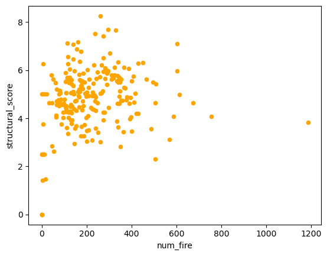

Figure 14. No. of Fire Incidents per Postcode District vs Ave ConfidenceInManagement Score (Lower is Better)  
Pearson correlation coefficient: 0.1895

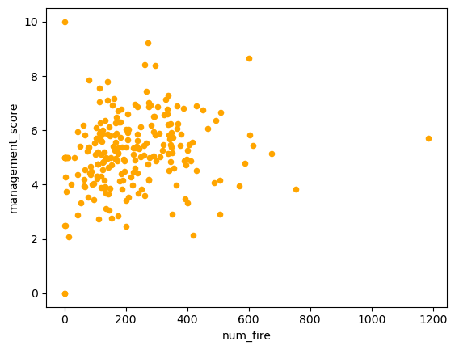

This graph shows little correlation between an establishment’s average rating and the number of fire incidents per postcode district.

Figure 15. No. of Fire Incidents per Postcode District vs Ave Rating (Higher is Better)  
Pearson correlation coefficient: -0.2558

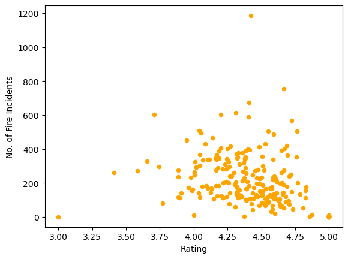

Among food establishments, restaurants and cafes make up the majority of fire incident reports.

Figure 16. Reported No. of Fire Incidents per Food Establishment Type in `hygiene` table

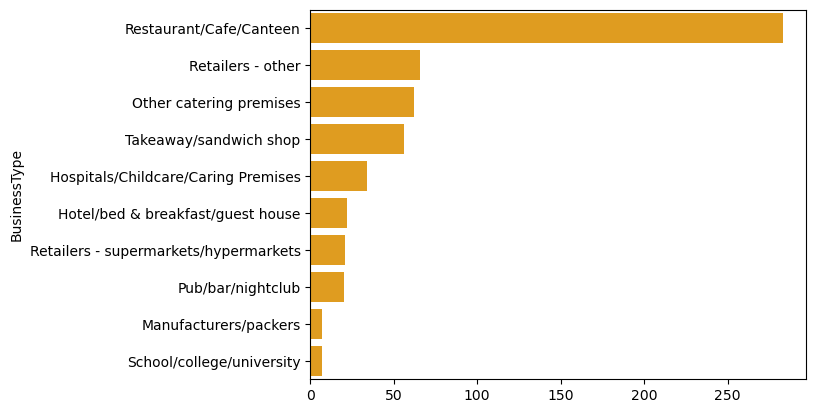

### Exploring the *Restaurant/Cafe/Canteen* `BusinessType`

Figure 17. Count of Restaurant/Cafe/Canteen BusinessType with fire incident per Score in `hygiene` table

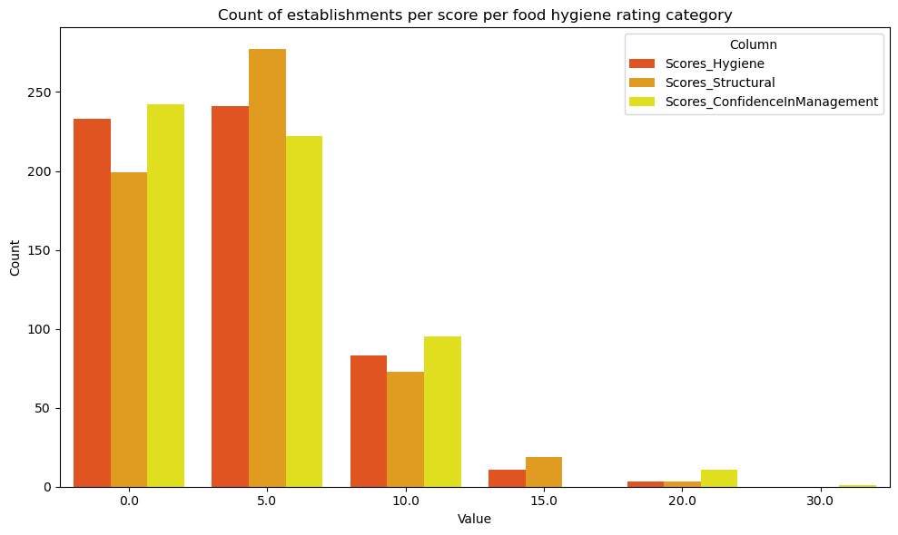

Majority of the `Score_Structural` were ranging from 0.0-5.0 which means that the establishments under this `BusinessType` has good rating, wehreas a score of 20.0 means the worst score

Figure 18. Count of Restaurant/Cafe/Canteen BusinessType with fire incident per Rating in `hygiene` table

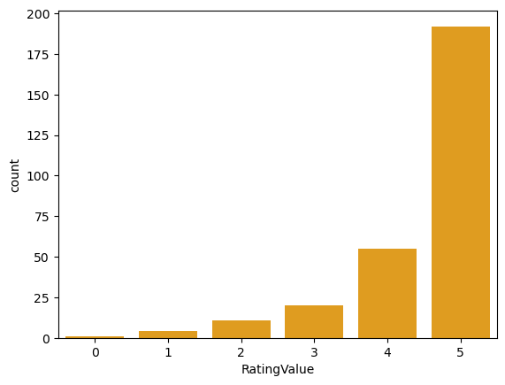

### From these two bar graphs, we can see that the `Score_Structural` and `Rating_Value` has no impact with the fire incident

### Exploring establishments that caught on fire multiple times

Figure 19. Top 10 Businesses with highest No. of fire incidents

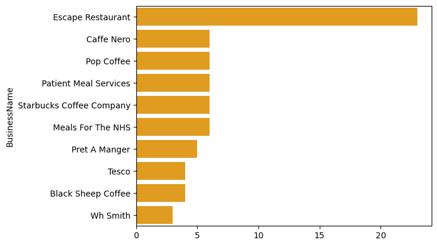

#### In this graph we can see that an establishment called *Escape Restaurant* had caught on fire incident 23 times, the fire incident happened between 2018-2022, whereas *Escape Restaurant* was rated 4/5, this 2023. Which shows that the past fire incident didn't affect the `Rating_Value` of this establishment

With around 250 establishments as a *Restaurant/Cafe/Canteen*, majority of them has a `Rating_Value` of 5 which signifies that the estbalishment has an almost perfect scores throughtout the criteria

Among `582` establishsments in `hygiene` table that caught on fire, *Restaurant/Cafe/Canteen* had the most incident having more than 250 incidents.

# Results

### Number of Establishments and Fire

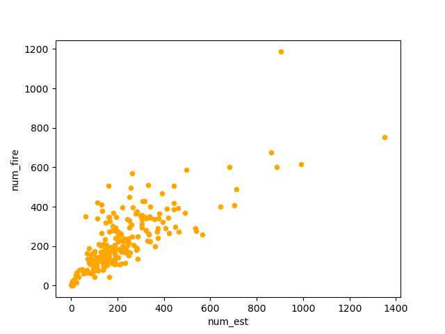

##### Pearson r = .79 (moderate correlation)

### Hygeine Scores and Fire Incidence per Postcode Disctrict

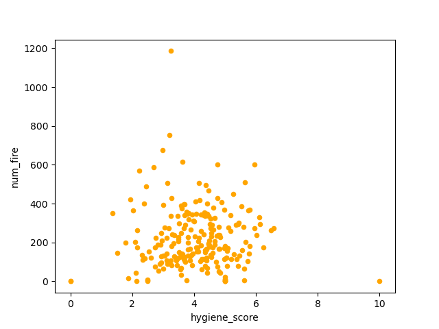

##### Pearson r = .02 (negligible correlation)

### Structural Scores and Fire Incidence per Postcode Disctrict

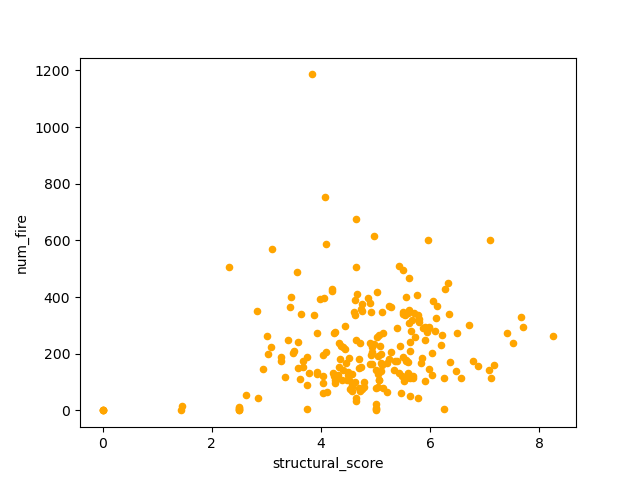

### Management Scores and Fire Incidence per Postcode Disctrict

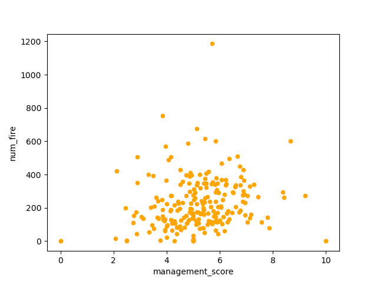

##### Pearson r = .19 (weak correlation)

# Discussion and Recommendations

In this section, we present the results of our data analysis, outlining the findings related to the two primary objectives of our study.

*Number of Restaurants and Fire Incidence*

Our analysis revealed a statistically significant positive correlation (r = 0.79) between the number of restaurants per postcode and the frequency of fire incidents.

## Discussion

As expected, correlation suggests that postcodes with a higher concentration of restaurants tend to have more fire incidents. The positive correlation coefficient indicates that as the number of restaurants in a postcode increases, so does the likelihood of fire incidents. While this relationship does not definitively state that an increase of restaurants directly leads to increased fires, it provides reason to investigate further. Initial assumptions of this relationship may be attributed to the fact kitchens are high-risk environments due to the presence of open flames, hot surfaces and flammable materials.

The lack of a significant correlation between food safety ratings and fire incidents suggests that food safety standards are an insufficient proxy for fire risk, in fact beaten by the low-hanging fruit of restaurant density. Now a low correlation does not necessarily imply that there is no connection between the two factors. Perhaps there may be other mediating factors not covered by the data that explains this.

The study was interested in the relationship between food safety ratings and fire incidence, because one could assume that businesses engaged in poor safety practices in a high-hazard environment where fire can easily start and spread. However, the lack of statistical significance in the data would suggest otherwise.

## Recommendations

The fact that there is a moderately positive relationship between the density of restaurants and fire incidence allows insight for policymakers and safety officials. It suggests that there should be greater scrutiny placed in these areas, or at least the presence of response teams should be heavier there. The data even suggests that increasing food hygiene and safety may not be the best way to reduce incidences of fire, and further research would be necessary in creating more exact solutions.

For the policymakers, these findings would suggest that London officials should consider fire risks when permitting a high concentration of restaurants in a particular area. Safer zoning laws where high-density areas are interspersed with open spaces or other types of establishments.

However, further research may also be conducted to at least examine what exact factors these ratings might be contributing to fire incidence even if it is weak in comparison. It could be specific practices or equipment used in establishments with lower hygiene ratings. Qualitative study may be conducted to gain further insight as to what causes the fires in these establishments.

Taking these findings all together, a vital first step would be to examine areas with high restaurant density and conduct comprehensive safety audits that assess both fire safety measures and food hygiene practices. While they might not be strongly related, ensuring both are up to standard can enhance overall safety.

# References

- Food Safety Agency (2018, July 27). UK food hygiene rating data (London) - Food Standards Agency. Www.data.gov.uk. https://www.data.gov.uk/dataset/e945d1f5-72fe-4b08-8b58-8e68d83441b5/uk-food-hygiene-rating-data-london-food-standards-agency
- London Data Store “London Fire Brigade Incident Records – London Datastore.” London.gov.uk, 2011, data.london.gov.uk/dataset/london-fire-brigade-incident-records.